# Homework 2

## Mustafa Mert Türkmen 21902576

```r
data(Auto,package= "ISLR2")
head(Auto)
```

```
  mpg cylinders displacement horsepower weight acceleration year origin
1  18         8          307        130   3504         12.0   70      1
2  15         8          350        165   3693         11.5   70      1
3  18         8          318        150   3436         11.0   70      1
4  16         8          304        150   3433         12.0   70      1
5  17         8          302        140   3449         10.5   70      1
6  15         8          429        198   4341         10.0   70      1
                       name
1 chevrolet chevelle malibu
2         buick skylark 320
3        plymouth satellite
4             amc rebel sst
5               ford torino
6          ford galaxie 500
```

```r
str(Auto)
```

```
'data.frame':   392 obs. of  9 variables:
 $ mpg         : num  18 15 18 16 17 15 14 14 14 15 ...
 $ cylinders   : int  8 8 8 8 8 8 8 8 8 8 ...
 $ displacement: num  307 350 318 304 302 429 454 440 455 390 ...
 $ horsepower  : int  130 165 150 150 140 198 220 215 225 190 ...
 $ weight      : int  3504 3693 3436 3433 3449 4341 4354 4312 4425 3850 ...
 $ acceleration: num  12 11.5 11 12 10.5 10 9 8.5 10 8.5 ...
 $ year        : int  70 70 70 70 70 70 70 70 70 70 ...
 $ origin      : int  1 1 1 1 1 1 1 1 1 1 ...
 $ name        : Factor w/ 304 levels "amc ambassador brougham",..: 49 36 231 14 161 141 54 223 241 2 ...
 - attr(*, "na.action")= 'omit' Named int [1:5] 33 127 331 337 355
  ..- attr(*, "names")= chr [1:5] "33" "127" "331" "337" ...
```

```r
summary(Auto)
```

```
      mpg          cylinders      displacement     horsepower        weight
 Min.   : 9.00   Min.   :3.000   Min.   : 68.0   Min.   : 46.0   Min.   :1613
 1st Qu.:17.00   1st Qu.:4.000   1st Qu.:105.0   1st Qu.: 75.0   1st Qu.:2225
 Median :22.75   Median :4.000   Median :151.0   Median : 93.5   Median :2804
 Mean   :23.45   Mean   :5.472   Mean   :194.4   Mean   :104.5   Mean   :2978
 3rd Qu.:29.00   3rd Qu.:8.000   3rd Qu.:275.8   3rd Qu.:126.0   3rd Qu.:3615
 Max.   :46.60   Max.   :8.000   Max.   :455.0   Max.   :230.0   Max.   :5140

  acceleration        year           origin                      name
 Min.   : 8.00   Min.   :70.00   Min.   :1.000   amc matador       :  5
 1st Qu.:13.78   1st Qu.:73.00   1st Qu.:1.000   ford pinto        :  5
 Median :15.50   Median :76.00   Median :1.000   toyota corolla    :  5
 Mean   :15.54   Mean   :75.98   Mean   :1.577   amc gremlin       :  4
 3rd Qu.:17.02   3rd Qu.:79.00   3rd Qu.:2.000   amc hornet        :  4
 Max.   :24.80   Max.   :82.00   Max.   :3.000   chevrolet chevette:  4
                                                 (Other)           :365
```

# 9

## 9.a

- **Qualitative Data**: origin, name
- **Quantitative Data**: mpg, cylinders, displacement, horsepower, weight, acceleration, year

## 9.b

```r
ranges <- sapply(Auto[,1:7], range)
ranges
```

```
      mpg cylinders displacement horsepower weight acceleration year
[1,]  9.0         3           68         46   1613          8.0   70
[2,] 46.6         8          455        230   5140         24.8   82
```

- In range function it gives us a vector containing min and max. First one defines min’s and second the max’s.

## 9.c

- Means

```r
means <- sapply(Auto[,1:7], mean)
means
```

```
         mpg    cylinders displacement   horsepower       weight acceleration
   23.445918     5.471939   194.411990   104.469388  2977.584184    15.541327
        year
   75.979592
```

- Standard Deviations

```r
sdevs <- sapply(Auto[,1:7], sd)
sdevs
```

```
         mpg    cylinders displacement   horsepower       weight acceleration
    7.805007     1.705783   104.644004    38.491160   849.402560     2.758864
        year
    3.683737
```

## 9.d

- I extract 10th to 85th with using combine function.

```r
autodata <- Auto[-c(10:85),]
```

- Range

```r
reduced_ranges <- sapply(autodata[,1:7], range)
reduced_ranges
```

```
      mpg cylinders displacement horsepower weight acceleration year
[1,] 11.0         3           68         46   1649          8.5   70
[2,] 46.6         8          455        230   4997         24.8   82
```

- Mean

```r
reduced_means <- sapply(autodata[,1:7], mean)
reduced_means
```

```
         mpg    cylinders displacement   horsepower       weight acceleration
   24.404430     5.373418   187.240506   100.721519  2935.971519    15.726899
        year
   77.145570
```

- Standard Deviation

```r
reduced_sdevs <- sapply(autodata[,1:7], sd)
reduced_sdevs
```

```
         mpg    cylinders displacement   horsepower       weight acceleration
    7.867283     1.654179    99.678367    35.708853   811.300208     2.693721
        year
    3.106217
```

## 9.e

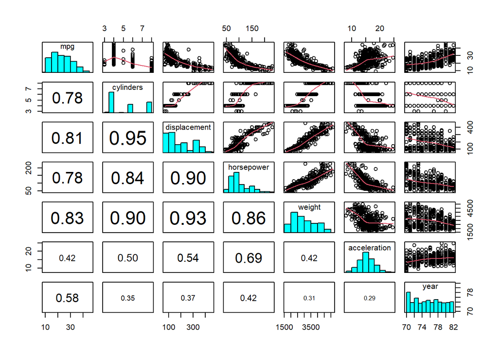

```r
panel.hist <- function(x, ...)
{
    usr <- par("usr")
    par(usr = c(usr[1:2], 0, 1.5) )
    h <- hist(x, plot = FALSE)
    breaks <- h$breaks; nB <- length(breaks)
    y <- h$counts; y <- y/max(y)
    rect(breaks[-nB], 0, breaks[-1], y, col = "cyan", ...)
}
panel.cor <- function(x, y, digits = 2, prefix = "", cex.cor, ...)
{
    par(usr = c(0, 1, 0, 1))
    r <- abs(cor(x, y))
    txt <- format(c(r, 0.123456789), digits = digits)[1]
    txt <- paste0(prefix, txt)
    if(missing(cex.cor)) cex.cor <- 0.8/strwidth(txt)
    text(0.5, 0.5, txt, cex = cex.cor * r)
}
pairs(Auto[,1:7], upper.panel = panel.smooth, lower.panel = panel.cor,
      diag.panel = panel.hist)
```

- Looking to pair plots and the correlation between them, I can state that there are linear relationships between some variables.
- Looking at mpg and relation between other variables shows me there are strong negative relations with for example displacement, horsepower, and weight. There is also positive correlation which is between mpg and year.
- The other variables have also strong positive and negative relations for instance horsepower and weight is positively correlated, and displacement has positive relation with horsepower and weight.
- There might be other relation between variables, also there may be relations with their origins but finding them needs further investigation.

## 9.f

- We can suggest to predict mpg by looking the plots and the correlation.
- Increasing displacement, horsepower and weight will reduce the mpg.
- Newer models will have high mpg.

```r
res <- lm(formula = mpg ~ displacement + horsepower + weight + year, data = autodata)
summary(res)
```

```
Call:
lm(formula = mpg ~ displacement + horsepower + weight + year,
    data = autodata)

Residuals:
    Min      1Q  Median      3Q     Max
-8.4476 -2.4781 -0.2918  2.1017 14.0804

Coefficients:
               Estimate Std. Error t value Pr(>|t|)
(Intercept)  -2.210e+01  5.945e+00  -3.718 0.000238 ***
displacement  8.673e-03  6.712e-03   1.292 0.197271
horsepower   -1.320e-02  1.292e-02  -1.022 0.307791
weight       -7.288e-03  7.253e-04 -10.048  < 2e-16 ***
year          8.764e-01  7.313e-02  11.984  < 2e-16 ***
---
Signif. codes:  0 '***' 0.001 '**' 0.01 '*' 0.05 '.' 0.1 ' ' 1

Residual standard error: 3.575 on 311 degrees of freedom
Multiple R-squared:  0.7962,    Adjusted R-squared:  0.7936
F-statistic: 303.7 on 4 and 311 DF,  p-value: < 2.2e-16
```

- Looking the linear model, I can say that there is a negative relation between mpg and weight, also there is a positive relation between mpg and year.
- However I could not reject the null hypothesis that there is no relation between displacement and horsepower with mpg maybe looking them seperate give a inside info.

```r
res <- lm(formula = mpg ~ displacement + horsepower, data = autodata)
summary(res)
```

```
Call:
lm(formula = mpg ~ displacement + horsepower, data = autodata)

Residuals:
     Min       1Q   Median       3Q      Max
-12.2349  -3.2950  -0.5312   2.5077  16.0138

Coefficients:
              Estimate Std. Error t value Pr(>|t|)
(Intercept)  38.532418   0.873972  44.089  < 2e-16 ***
displacement -0.044462   0.005894  -7.544 4.99e-13 ***
horsepower   -0.057613   0.016451  -3.502 0.000529 ***
---
Signif. codes:  0 '***' 0.001 '**' 0.01 '*' 0.05 '.' 0.1 ' ' 1

Residual standard error: 4.675 on 313 degrees of freedom
Multiple R-squared:  0.6491,    Adjusted R-squared:  0.6468
F-statistic: 289.5 on 2 and 313 DF,  p-value: < 2.2e-16
```

- Looking both in different model that I can say there is negative relation between displacement and horsepower with mpg.

# 10

## 10.a

```r
dim(Boston)
```

```
[1] 506  13
```

- 506 rows (suburbs)
- 13 columns (predictors)

crim per capita crime rate by town.

zn proportion of residential land zoned for lots over 25,000 sq.ft.

indus proportion of non-retail business acres per town.

chas Charles River dummy variable (= 1 if tract bounds river; 0 otherwise).

nox nitrogen oxides concentration (parts per 10 million).

rm average number of rooms per dwelling.

age proportion of owner-occupied units built prior to 1940.

dis weighted mean of distances to five Boston employment centres.

rad index of accessibility to radial highways.

tax full-value property-tax rate per $10,000.

ptratio pupil-teacher ratio by town.

lstat lower status of the population (percent).

medv median value of owner-occupied homes in $1000s.

## 10.b

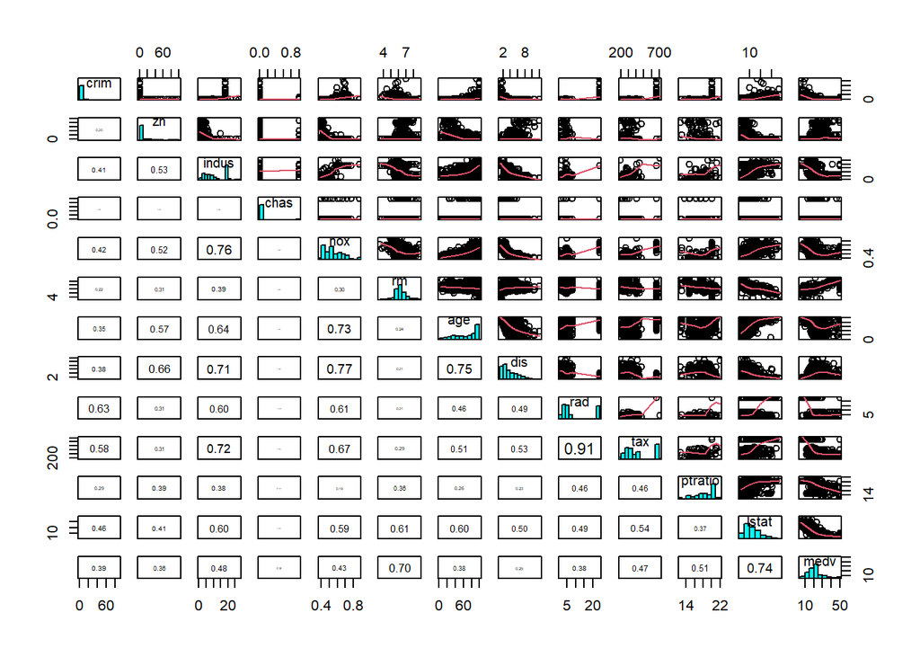

```r
panel.hist <- function(x, ...)
{
    usr <- par("usr")
    par(usr = c(usr[1:2], 0, 1.5) )
    h <- hist(x, plot = FALSE)
    breaks <- h$breaks; nB <- length(breaks)
    y <- h$counts; y <- y/max(y)
    rect(breaks[-nB], 0, breaks[-1], y, col = "cyan", ...)
}
panel.cor <- function(x, y, digits = 2, prefix = "", cex.cor, ...)
{
    par(usr = c(0, 1, 0, 1))
    r <- abs(cor(x, y))
    txt <- format(c(r, 0.123456789), digits = digits)[1]
    txt <- paste0(prefix, txt)
    if(missing(cex.cor)) cex.cor <- 0.8/strwidth(txt)
    text(0.5, 0.5, txt, cex = cex.cor * r)
}
pairs(Boston[,], upper.panel = panel.smooth, lower.panel = panel.cor,
      diag.panel = panel.hist)
```

- It is hard to see the pairwise relations between them. However I see some correlation value and pairwise scatterplots to deeply look.

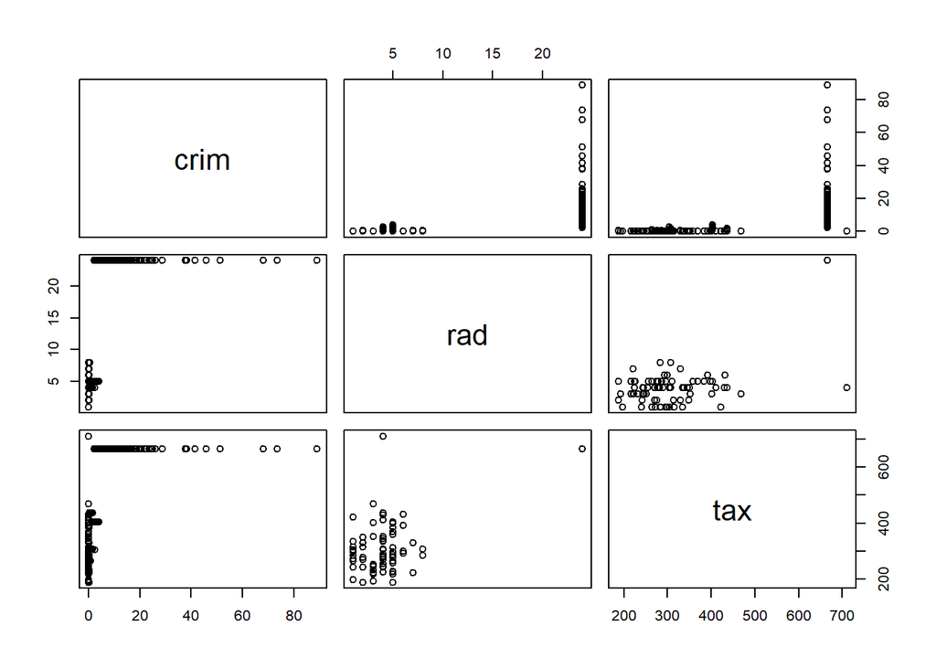

```r
pairs(~crim+rad+tax, data = Boston)
```

- Just looking I can say crim has may be positive relation with rad and tax however it show to me as a not strong.

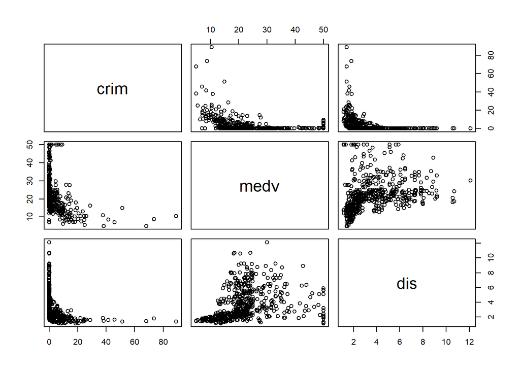

```r
pairs(~crim+medv+dis, data = Boston)
```

- There might be negative relation with crim of both medv and dis.
- Dis and medv might have positive relation.

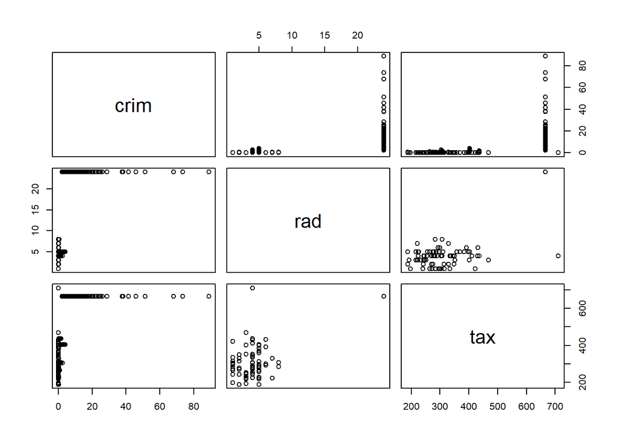

```r
pairs(~crim+rad+tax, data = Boston)
```

- Crim might have positive relation with rad and tax.
- Rad and tax has a positive relation.

## 10.c

```r
cor(Boston[1], Boston[-1])
```

```
             zn     indus        chas       nox         rm       age        dis
crim -0.2004692 0.4065834 -0.05589158 0.4209717 -0.2192467 0.3527343 -0.3796701
           rad       tax   ptratio     lstat       medv
crim 0.6255051 0.5827643 0.2899456 0.4556215 -0.3883046
```

- crim has a negative relationship with medv and dis.
- crim has a positive relationship with indus, nox, rad and tax.
- They are not strong relations.

## 10.d

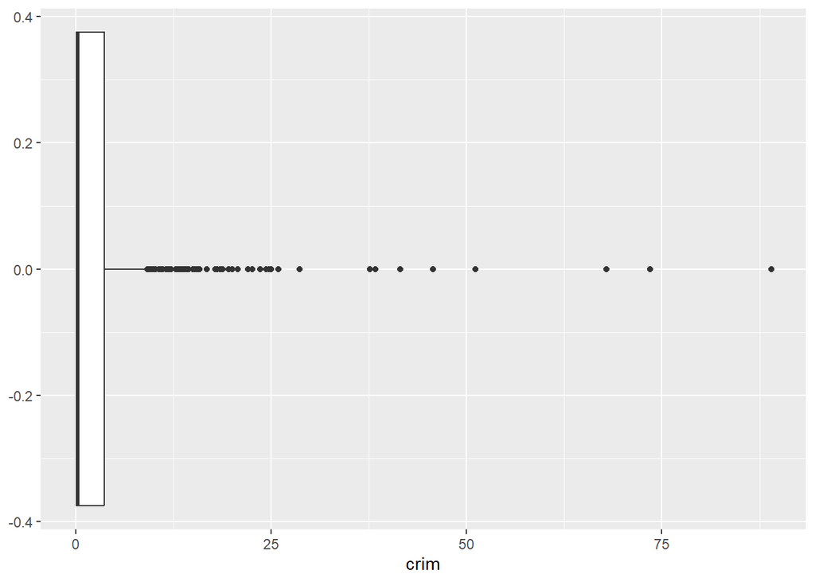

```r
Boston %>%
  ggplot(aes(crim)) +
  geom_boxplot()
```

- We can say that most suburbs have a crime rate at 0 or close to it. However, there are som suburbs that have high crime rates.

```r
summary(Boston$crim)
```

```
    Min.  1st Qu.   Median     Mean  3rd Qu.     Max.
 0.00632  0.08204  0.25651  3.61352  3.67708 88.97620
```

- The range is wide, it is between 0 to 89.

```r
sd(Boston$crim)
```

```
[1] 8.601545
```

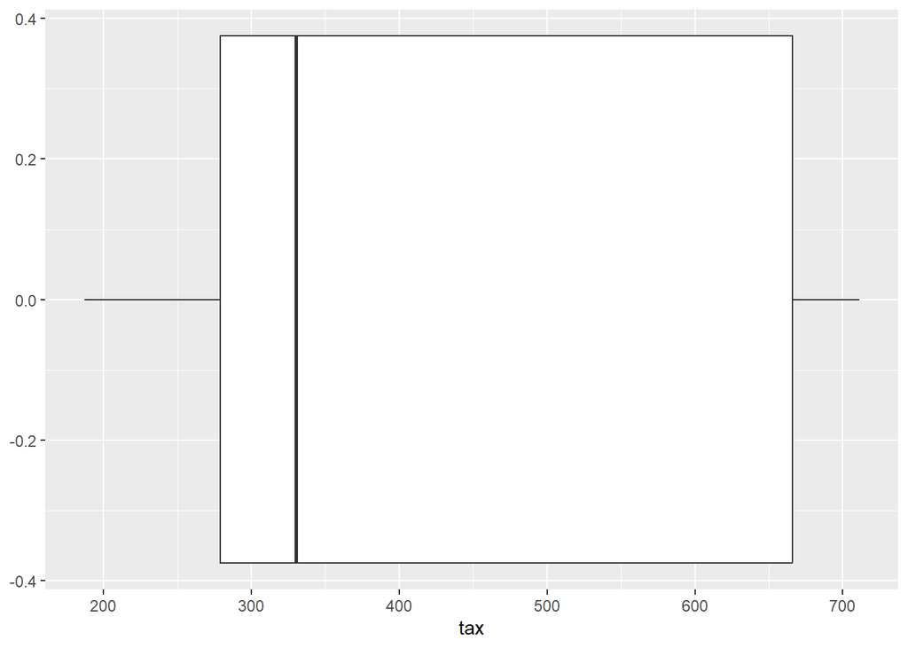

```r
Boston %>%
  ggplot(aes(tax)) +
  geom_boxplot()
```

- May be seeing it in histogram may give us better understand.

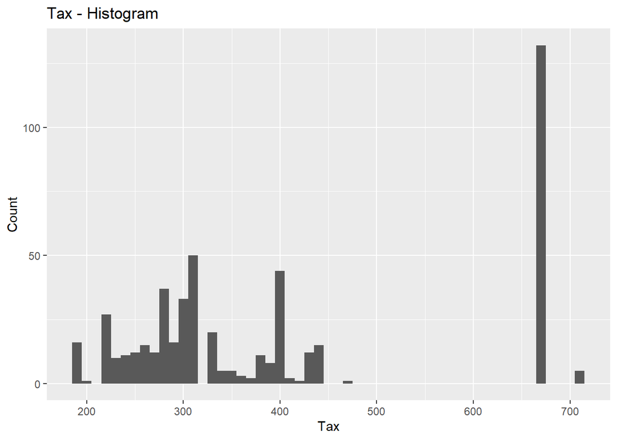

```r
ggplot(Boston, aes(x = tax)) +
  geom_histogram(binwidth = 10) +
  labs(title = "Tax - Histogram",
       x = "Tax",
       y = "Count")
```

- There are so many suburbs with high and same tax values.

```r
summary(Boston$tax)
```

```
   Min. 1st Qu.  Median    Mean 3rd Qu.    Max.
  187.0   279.0   330.0   408.2   666.0   711.0
```

- Range is again wide but not as much as crime rate I thinks based on percentage.

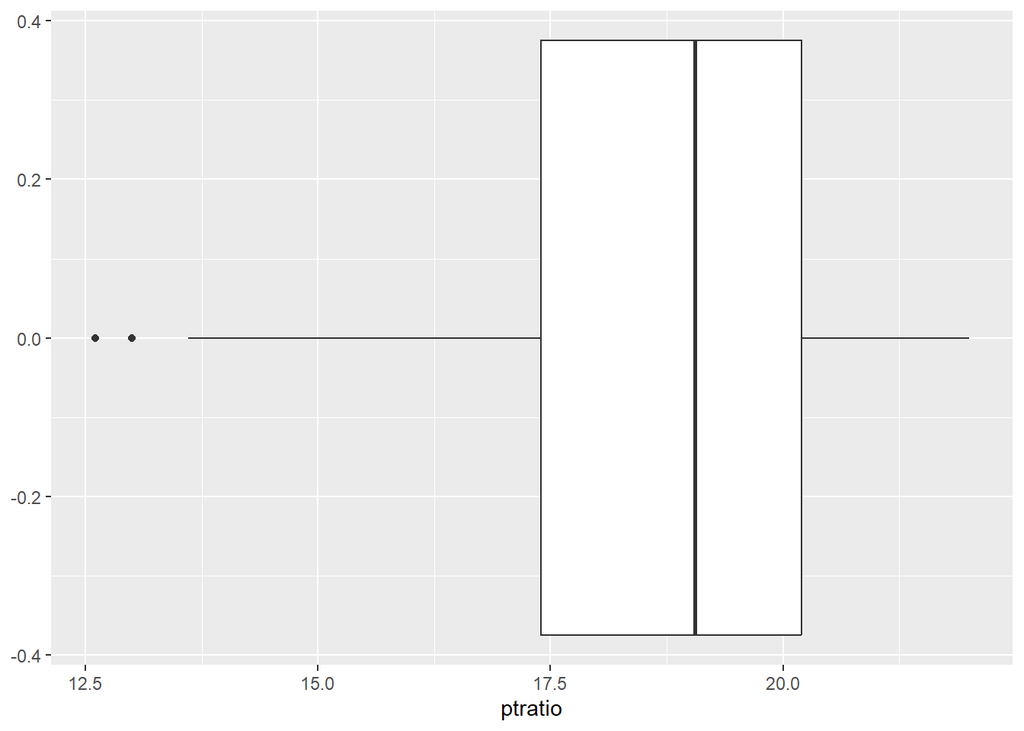

```r
Boston %>%
  ggplot(aes(ptratio)) +
  geom_boxplot()
```

```r
summary(Boston$ptratio)
```

```
   Min. 1st Qu.  Median    Mean 3rd Qu.    Max.
  12.60   17.40   19.05   18.46   20.20   22.00
```

- The range is narrow.

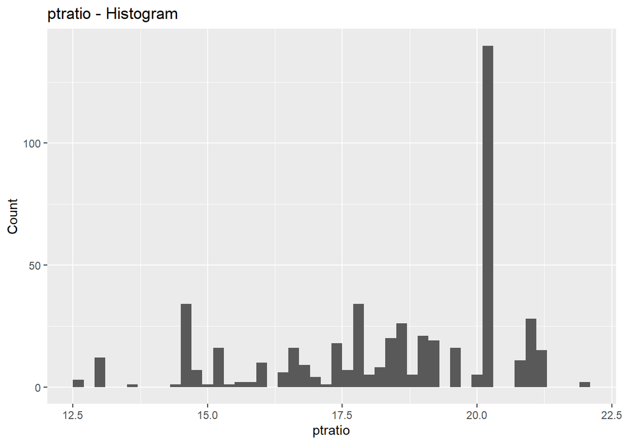

```r
ggplot(Boston, aes(x = ptratio)) +
  geom_histogram(binwidth = 0.2) +
  labs(title = "ptratio - Histogram",
       x = "ptratio",
       y = "Count")
```

- There are so many observation in the same value just like tax rates.
- I think the ptratio and tax rate may have relation so lets check.

```r
Boston %>%
  group_by(ptratio, tax) %>%
  count() %>%
  arrange(desc(n))
```

```
# A tibble: 78 × 3
# Groups:   ptratio, tax [78]
   ptratio   tax     n
     <dbl> <dbl> <int>
 1    20.2   666   132
 2    14.7   403    30
 3    21     307    22
 4    17.4   307    18
 5    21.2   437    15
 6    13     264    12
 7    18.4   304    12
 8    18.6   277    11
 9    20.9   384    11
10    19.1   330    10
# ℹ 68 more rows
```

- Just like I thought there are 132 suburbs which has same ptratio and tax ratio. Thats interesting to observe.

## 10.e

- Recall; chas Charles River dummy variable (= 1 if tract bounds river; 0 otherwise).

```r
sum(Boston$chas==1)
```

```
[1] 35
```

- 35 suburbs bound the Charles River.

## 10.f

```r
summary(Boston$ptratio)
```

```
   Min. 1st Qu.  Median    Mean 3rd Qu.    Max.
  12.60   17.40   19.05   18.46   20.20   22.00
```

- Median is equal to 19.05

## 10.g

```r
which(Boston$medv == min(Boston$medv))
```

```
[1] 399 406
```

- 399 and 406 have the lowest median value of properties.

```r
Boston[c(399,406),]
```

```
       crim zn indus chas   nox    rm age    dis rad tax ptratio lstat medv
399 38.3518  0  18.1    0 0.693 5.453 100 1.4896  24 666    20.2 30.59    5
406 67.9208  0  18.1    0 0.693 5.683 100 1.4254  24 666    20.2 22.98    5
```

- Understanding from there is hard, but I can comment of some predictors.
- Crime rates are high, 406 has more crime rates than 399.
- They have same ptratio and tax rate which is common for other suburbs.
- They are not near to Charles river they have 0 in chas.

```r
summary(Boston)
```

```
      crim                zn             indus            chas
 Min.   : 0.00632   Min.   :  0.00   Min.   : 0.46   Min.   :0.00000
 1st Qu.: 0.08205   1st Qu.:  0.00   1st Qu.: 5.19   1st Qu.:0.00000
 Median : 0.25651   Median :  0.00   Median : 9.69   Median :0.00000
 Mean   : 3.61352   Mean   : 11.36   Mean   :11.14   Mean   :0.06917
 3rd Qu.: 3.67708   3rd Qu.: 12.50   3rd Qu.:18.10   3rd Qu.:0.00000
 Max.   :88.97620   Max.   :100.00   Max.   :27.74   Max.   :1.00000
      nox               rm             age              dis
 Min.   :0.3850   Min.   :3.561   Min.   :  2.90   Min.   : 1.130
 1st Qu.:0.4490   1st Qu.:5.886   1st Qu.: 45.02   1st Qu.: 2.100
 Median :0.5380   Median :6.208   Median : 77.50   Median : 3.207
 Mean   :0.5547   Mean   :6.285   Mean   : 68.57   Mean   : 3.795
 3rd Qu.:0.6240   3rd Qu.:6.623   3rd Qu.: 94.08   3rd Qu.: 5.188
 Max.   :0.8710   Max.   :8.780   Max.   :100.00   Max.   :12.127
      rad              tax           ptratio          lstat
 Min.   : 1.000   Min.   :187.0   Min.   :12.60   Min.   : 1.73
 1st Qu.: 4.000   1st Qu.:279.0   1st Qu.:17.40   1st Qu.: 6.95
 Median : 5.000   Median :330.0   Median :19.05   Median :11.36
 Mean   : 9.549   Mean   :408.2   Mean   :18.46   Mean   :12.65
 3rd Qu.:24.000   3rd Qu.:666.0   3rd Qu.:20.20   3rd Qu.:16.95
 Max.   :24.000   Max.   :711.0   Max.   :22.00   Max.   :37.97
      medv
 Min.   : 5.00
 1st Qu.:17.02
 Median :21.20
 Mean   :22.53
 3rd Qu.:25.00
 Max.   :50.00
```

- They are close to Boston employment centers.
- They have lower status of population.

## 10.h

```r
sum(Boston$rm >7)
```

```
[1] 64
```

- 64 census tract has more than 7 avg. no. of rooms per dwelling.

```r
sum(Boston$rm >8)
```

```
[1] 13
```

- 13 census tract has more than 8 avg. no. of rooms per dwelling.

```r
summary(Boston)
```

```
      crim                zn             indus            chas
 Min.   : 0.00632   Min.   :  0.00   Min.   : 0.46   Min.   :0.00000
 1st Qu.: 0.08205   1st Qu.:  0.00   1st Qu.: 5.19   1st Qu.:0.00000
 Median : 0.25651   Median :  0.00   Median : 9.69   Median :0.00000
 Mean   : 3.61352   Mean   : 11.36   Mean   :11.14   Mean   :0.06917
 3rd Qu.: 3.67708   3rd Qu.: 12.50   3rd Qu.:18.10   3rd Qu.:0.00000
 Max.   :88.97620   Max.   :100.00   Max.   :27.74   Max.   :1.00000
      nox               rm             age              dis
 Min.   :0.3850   Min.   :3.561   Min.   :  2.90   Min.   : 1.130
 1st Qu.:0.4490   1st Qu.:5.886   1st Qu.: 45.02   1st Qu.: 2.100
 Median :0.5380   Median :6.208   Median : 77.50   Median : 3.207
 Mean   :0.5547   Mean   :6.285   Mean   : 68.57   Mean   : 3.795
 3rd Qu.:0.6240   3rd Qu.:6.623   3rd Qu.: 94.08   3rd Qu.: 5.188
 Max.   :0.8710   Max.   :8.780   Max.   :100.00   Max.   :12.127
      rad              tax           ptratio          lstat
 Min.   : 1.000   Min.   :187.0   Min.   :12.60   Min.   : 1.73
 1st Qu.: 4.000   1st Qu.:279.0   1st Qu.:17.40   1st Qu.: 6.95
 Median : 5.000   Median :330.0   Median :19.05   Median :11.36
 Mean   : 9.549   Mean   :408.2   Mean   :18.46   Mean   :12.65
 3rd Qu.:24.000   3rd Qu.:666.0   3rd Qu.:20.20   3rd Qu.:16.95
 Max.   :24.000   Max.   :711.0   Max.   :22.00   Max.   :37.97
      medv
 Min.   : 5.00
 1st Qu.:17.02
 Median :21.20
 Mean   :22.53
 3rd Qu.:25.00
 Max.   :50.00
```

```r
summary(subset(Boston, rm>8))
```

```
      crim               zn            indus             chas
 Min.   :0.02009   Min.   : 0.00   Min.   : 2.680   Min.   :0.0000
 1st Qu.:0.33147   1st Qu.: 0.00   1st Qu.: 3.970   1st Qu.:0.0000
 Median :0.52014   Median : 0.00   Median : 6.200   Median :0.0000
 Mean   :0.71879   Mean   :13.62   Mean   : 7.078   Mean   :0.1538
 3rd Qu.:0.57834   3rd Qu.:20.00   3rd Qu.: 6.200   3rd Qu.:0.0000
 Max.   :3.47428   Max.   :95.00   Max.   :19.580   Max.   :1.0000
      nox               rm             age             dis
 Min.   :0.4161   Min.   :8.034   Min.   : 8.40   Min.   :1.801
 1st Qu.:0.5040   1st Qu.:8.247   1st Qu.:70.40   1st Qu.:2.288
 Median :0.5070   Median :8.297   Median :78.30   Median :2.894
 Mean   :0.5392   Mean   :8.349   Mean   :71.54   Mean   :3.430
 3rd Qu.:0.6050   3rd Qu.:8.398   3rd Qu.:86.50   3rd Qu.:3.652
 Max.   :0.7180   Max.   :8.780   Max.   :93.90   Max.   :8.907
      rad              tax           ptratio          lstat           medv
 Min.   : 2.000   Min.   :224.0   Min.   :13.00   Min.   :2.47   Min.   :21.9
 1st Qu.: 5.000   1st Qu.:264.0   1st Qu.:14.70   1st Qu.:3.32   1st Qu.:41.7
 Median : 7.000   Median :307.0   Median :17.40   Median :4.14   Median :48.3
 Mean   : 7.462   Mean   :325.1   Mean   :16.36   Mean   :4.31   Mean   :44.2
 3rd Qu.: 8.000   3rd Qu.:307.0   3rd Qu.:17.40   3rd Qu.:5.12   3rd Qu.:50.0
 Max.   :24.000   Max.   :666.0   Max.   :20.20   Max.   :7.44   Max.   :50.0
```

- They have low crime rates.
- They have higher median value of owner-occupied homes.
- They have relatively less lower status of the population.
- They have relatively close to employment centers.